# Bitcoin Financial Data Exploration

## Preliminary Wrangling

This document explores a dataset containing finanical information for the top 10 cryptocurrencies by marketcap from 2013-2019. Data was pulled from CoinMarketCap.com. Attributes of dataset include: Currency(e.g. bitcoin), Date, Open, Close, High, Low,, Volume, Market Cap.

**Import** all packages

```python
import numpy as np
import pandas as pd
import seaborn as sns
import matplotlib as mpl
import matplotlib.pyplot as plt

%matplotlib inline
```

**Read** and explore the dataset

```python
df = pd.read_csv('consolidated_coin_data.csv', encoding = 'ISO-8859-1')
```

```python
df.head()
```

|  | Currency | Date | Open | High | Low | Close | Volume | Market Cap |
| --- | --- | --- | --- | --- | --- | --- | --- | --- |
| 0 | tezos | Dec 04, 2019 | 1.29 | 1.32 | 1.25 | 1.25 | 46,048,752 | 824,588,509 |
| 1 | tezos | Dec 03, 2019 | 1.24 | 1.32 | 1.21 | 1.29 | 41,462,224 | 853,213,342 |
| 2 | tezos | Dec 02, 2019 | 1.25 | 1.26 | 1.20 | 1.24 | 27,574,097 | 817,872,179 |
| 3 | tezos | Dec 01, 2019 | 1.33 | 1.34 | 1.25 | 1.25 | 24,127,567 | 828,296,390 |
| 4 | tezos | Nov 30, 2019 | 1.31 | 1.37 | 1.31 | 1.33 | 28,706,667 | 879,181,680 |

```python
df.info()
```

```
<class 'pandas.core.frame.DataFrame'>
RangeIndex: 28944 entries, 0 to 28943
Data columns (total 8 columns):
 #   Column      Non-Null Count  Dtype
---  ------      --------------  -----
 0   Currency    28944 non-null  object
 1   Date        28944 non-null  object
 2   Open        28944 non-null  object
 3   High        28944 non-null  object
 4   Low         28944 non-null  object
 5   Close       28944 non-null  object
 6   Volume      28944 non-null  object
 7   Market Cap  28944 non-null  object
dtypes: object(8)
memory usage: 1.8+ MB
```

> The original dataset contain 8 columns and 28944 rows. No missing values.

Check for duplicates rows

```python
df.duplicated().sum()
```

```
0
```

## Some Data Cleaning and Feature Engineering (creating new columns)

Make a copy of the original data (no reference)

```python
df_copy = df.copy()
```

### Transform columns

Rename all columns to lowercase

```python
df_copy.rename(str.lower, axis='columns', inplace=True);
```

Rename **Market Cap** to *market-cap*

```python
df_copy.rename(columns={'market cap': 'market_cap'}, inplace=True);
```

Preview columns

```python
df_copy.columns
```

```
Index(['currency', 'date', 'open', 'high', 'low', 'close', 'volume',
       'market_cap'],
      dtype='object')
```

Array all *numerical features*

```python
numeric_features = ['volume', 'market_cap', 'open', 'close', 'high', 'low']
```

Change **numerical features** to **float** type

```python
for feature in numeric_features:
    df_copy[feature] = df_copy[feature].str.replace(',', '')
    df_copy[feature] = df_copy[feature].astype('float')
```

Change the **date** column to **datetime**

```python
df_copy['date'] = pd.to_datetime(df_copy['date'])
```

Preview `df_copy`

```python
df_copy.info()
```

```
<class 'pandas.core.frame.DataFrame'>
RangeIndex: 28944 entries, 0 to 28943
Data columns (total 8 columns):
 #   Column      Non-Null Count  Dtype
---  ------      --------------  -----
 0   currency    28944 non-null  object
 1   date        28944 non-null  datetime64[ns]
 2   open        28944 non-null  float64
 3   high        28944 non-null  float64
 4   low         28944 non-null  float64
 5   close       28944 non-null  float64
 6   volume      28944 non-null  float64
 7   market_cap  28944 non-null  float64
dtypes: datetime64[ns](1), float64(6), object(1)
memory usage: 1.8+ MB
```

### Cleaning rows

Drop any row with multiple rows of same **currency** and **date**

```python
currencies = df_copy['currency'].value_counts().index
for currency in currencies:
    coin = df_copy[(df_copy['currency'] == currency)]
    value_counts = coin['date'].value_counts().reset_index(name="count").query("count > 1")["index"]
    for date in value_counts:
        # delete all rows with same column 'currency' and 'date' value
        indexAge = df_copy[ (df_copy['currency'] == currency) & (df_copy['date'] == date) ].index
        df_copy.drop(indexAge , inplace=True)
```

Drop any row in any **numerical features** with value 0 or less.

```python
for feature in numeric_features:
    df_copy = df_copy[df_copy[feature] > 0]
```

> All numerical column represent some form of value. I want all numerical features to have a positive monetary value for our analysis.

Preview the dataset

```python
df_copy.shape
```

```
(25711, 8)
```

About 3000 rows were deleted from `df_copy`.

### Feature Engineering (Creating new columns)

We are interested in knowing what time in year bitcoin performs better, when people invested in bitcoin the most, and which year bitcoin brought the highest return for investors?

However, our current dataset is limited to get this information. We will be adding three categorical features:

1. year
2. Quarters (Q1, Q2, Q3, Q4)
3. months (January - December)

These **categorical features** will be derived from the **date** feature. All we are doing is simply to categorize the **date** feature by extracting the month, quarter, and year.

#### Price

We are also going to create a numerical column called **price**. This column is the average of the **open**, **close**, **high**, and **low** column. It will help viewers who are not deep in crypto to take the price column as the actual price of a crypto on each date. Also, it will create clarity in the analysis.

Create column in `df_copy` called **year** which extracts the year from the **date** column

```python
df_copy['year'] = pd.DatetimeIndex(df_copy['date']).year
```

Create column in `df_copy` called **month** which extracts the year from the **date** column

```python
df_copy['month'] = pd.DatetimeIndex(df_copy['date']).month_name()
```

Create column in `df_copy` called **quarter** which extracts the quarter from the **date** column

```python
df_copy['quarter'] = pd.DatetimeIndex(df_copy['date']).quarter
```

Create column `df_copy` called **price** which is the average of the **open**, **close**, **high**, and **low** column.

```python
df_copy['price'] = df_copy[['close', 'open', 'high', 'low']].mean(axis=1)
```

Preview the dataset

```python
df_copy.head()
```

|  | currency | date | open | high | low | close | volume | market_cap | year | month | quarter | price |
| --- | --- | --- | --- | --- | --- | --- | --- | --- | --- | --- | --- | --- |
| 0 | tezos | 2019-12-04 | 1.29 | 1.32 | 1.25 | 1.25 | 46048752.0 | 824588509.0 | 2019 | December | 4 | 1.2775 |
| 1 | tezos | 2019-12-03 | 1.24 | 1.32 | 1.21 | 1.29 | 41462224.0 | 853213342.0 | 2019 | December | 4 | 1.2650 |
| 2 | tezos | 2019-12-02 | 1.25 | 1.26 | 1.20 | 1.24 | 27574097.0 | 817872179.0 | 2019 | December | 4 | 1.2375 |
| 3 | tezos | 2019-12-01 | 1.33 | 1.34 | 1.25 | 1.25 | 24127567.0 | 828296390.0 | 2019 | December | 4 | 1.2925 |
| 4 | tezos | 2019-11-30 | 1.31 | 1.37 | 1.31 | 1.33 | 28706667.0 | 879181680.0 | 2019 | November | 4 | 1.3300 |

## Bitcoin

I'm only interested in Bitcoin. So I will extract all rows from `df_copy` with **currency** bitcoin and drop the **currency** row.

```python
df_btc = df_copy[df_copy['currency'] == 'bitcoin'].copy()
df_btc.drop(['currency'], axis = 1, inplace = True)
```

```python
df_btc.head()
```

|  | date | open | high | low | close | volume | market_cap | year | month | quarter | price |
| --- | --- | --- | --- | --- | --- | --- | --- | --- | --- | --- | --- |
| 7236 | 2019-12-04 | 7320.13 | 7539.78 | 7170.92 | 7252.03 | 2.166424e+10 | 1.311431e+11 | 2019 | December | 4 | 7320.7150 |
| 7237 | 2019-12-03 | 7323.98 | 7418.86 | 7229.36 | 7320.15 | 1.479749e+10 | 1.323599e+11 | 2019 | December | 4 | 7323.0875 |
| 7238 | 2019-12-02 | 7424.04 | 7474.82 | 7233.40 | 7321.99 | 1.708204e+10 | 1.323790e+11 | 2019 | December | 4 | 7363.5625 |
| 7239 | 2019-12-01 | 7571.62 | 7571.62 | 7291.34 | 7424.29 | 1.872071e+10 | 1.342151e+11 | 2019 | December | 4 | 7464.7175 |
| 7240 | 2019-11-30 | 7764.06 | 7836.10 | 7515.85 | 7569.63 | 1.715819e+10 | 1.368294e+11 | 2019 | November | 4 | 7671.4100 |

```python
df_btc.info()
```

```
<class 'pandas.core.frame.DataFrame'>
Int64Index: 2169 entries, 7236 to 9404
Data columns (total 11 columns):
 #   Column      Non-Null Count  Dtype
---  ------      --------------  -----
 0   date        2169 non-null   datetime64[ns]
 1   open        2169 non-null   float64
 2   high        2169 non-null   float64
 3   low         2169 non-null   float64
 4   close       2169 non-null   float64
 5   volume      2169 non-null   float64
 6   market_cap  2169 non-null   float64
 7   year        2169 non-null   int64
 8   month       2169 non-null   object
 9   quarter     2169 non-null   int64
 10  price       2169 non-null   float64
dtypes: datetime64[ns](1), float64(7), int64(2), object(1)
memory usage: 203.3+ KB
```

```python
df_btc.describe()
```

|  | open | high | low | close | volume | market_cap | year | quarter | price |
| --- | --- | --- | --- | --- | --- | --- | --- | --- | --- |
| count | 2169.000000 | 2169.000000 | 2169.000000 | 2169.000000 | 2.169000e+03 | 2.169000e+03 | 2169.000000 | 2169.000000 | 2169.000000 |
| mean | 3331.591319 | 3422.836602 | 3232.321904 | 3334.505989 | 4.002383e+09 | 5.682918e+10 | 2016.460581 | 2.493776 | 3330.313953 |
| std | 3851.914045 | 3978.805638 | 3702.382479 | 3852.412012 | 6.786470e+09 | 6.708928e+10 | 1.701540 | 1.112692 | 3844.086378 |
| min | 176.900000 | 211.730000 | 171.510000 | 178.100000 | 2.857830e+06 | 2.444379e+09 | 2013.000000 | 1.000000 | 198.177500 |
| 25% | 429.580000 | 435.190000 | 422.080000 | 429.110000 | 3.397780e+07 | 6.294422e+09 | 2015.000000 | 2.000000 | 429.170000 |
| 50% | 845.460000 | 870.960000 | 823.560000 | 846.860000 | 1.361000e+08 | 1.252178e+10 | 2016.000000 | 2.000000 | 849.422500 |
| 75% | 6378.920000 | 6502.280000 | 6298.240000 | 6378.850000 | 5.132480e+09 | 1.103541e+11 | 2018.000000 | 3.000000 | 6398.247500 |
| max | 19475.800000 | 20089.000000 | 18974.100000 | 19497.400000 | 4.510573e+10 | 3.265025e+11 | 2019.000000 | 4.000000 | 19419.925000 |

I plan to use the bitcoin dataset for future analysis in a seperate notebook, so I will save it.

```python
df_btc.to_csv('bitcoin-cleaned-data.csv')
```

### What is/are the main feature(s) of interest in your dataset?

Trying to figure out what features can be used to predicting the price of Bitcoin. Also I would like to know at what price or time is best to purcase bitcoin.

### What features in the dataset do you think will help support your investigation into your feature(s) of interest?

I think market cap will have the strongest effect on Bitcoin price: the higher the market cap, the higher the price. I also think that volume will be a major influence and maybe date.

## Univariate Analysis

### Bitcoin Price

Histplot of bitcoin historical price

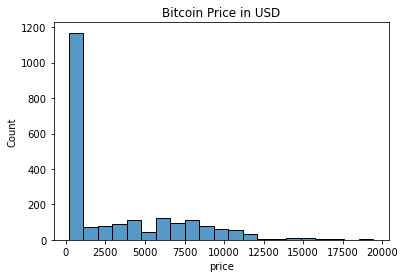

```python
sns.histplot(x='price', data=df_btc).set(title="Bitcoin Price in USD");
```

> Most of bitcoin prices in the dataset are less than 1000 USD. Other significant part ranges between 1000 - 12000 USD.

Rugplot for the daily **price**.

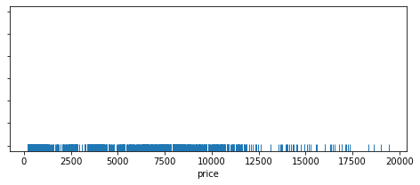

```python
plt.figure(figsize=(8, 3))
ax = sns.rugplot(x='price', data=df_btc, height=.05)
ax.set_yticklabels('')
plt.show()
```

> Interestingly, majority of the **price** for bitcoin fall under 12,000 USD. It may be highly risky to purchase bitcoin within this period for more than 12,000 USD.

A box plot and pass the **open** and **close** price in the data as below.

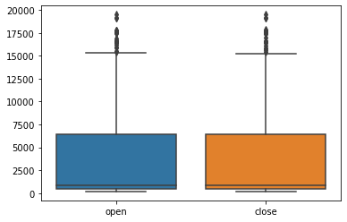

```python
sns.boxplot(data=df_btc.loc[:, ['open', 'close']])
```

> Aha! more interesting. While the rugplot above clearly shows majority of the price data falls a little below 12,000 USD, the **box plot** provide a better information on the price. Price above 6500 USD are maximum. It seems better to purchase Bitcoin at a price less than 6500 USD within the time period.

Box plot of all **price features** in the `df_btc` dataset.

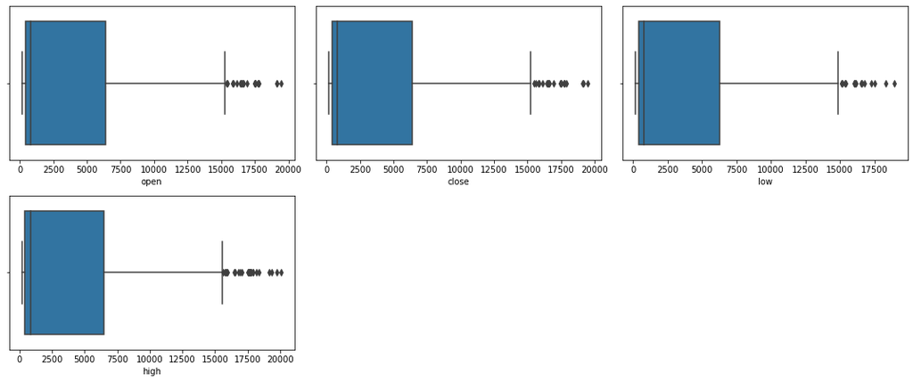

```python
cols = 3
rows = 3
price_cols = ['open', 'close', 'low', 'high']

fig = plt.figure(figsize= (15,9))

for i, col in enumerate(price_cols):

    ax=fig.add_subplot(rows, cols, i+1)

    sns.boxplot(x=df_btc[col], ax=ax)

fig.tight_layout()
plt.show()
```

> This further support our obversavation above.

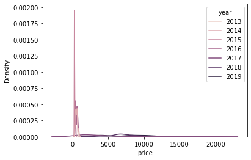

```python
sns.kdeplot(x='price', data=df_btc, hue='year');
```

### Market cap

**Price** is just one way to measure a cryptocurrency's value. Investors use **market cap** to tell a more complete story and compare value across cryptocurrencies. As a key statistic, it can indicate the growth potential of a cryptocurrency and whether it is safe to buy, compared to others.

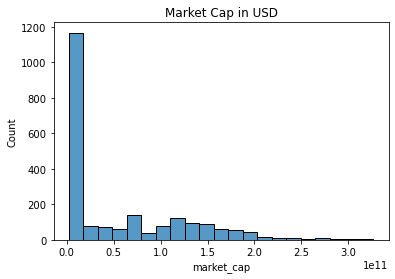

```python
sns.histplot(x='market_cap', data=df_btc).set(title="Market Cap in USD");
```

> The distribution of the market cap data is rightly skewed. And there are several large values, so I like to define my own scale.

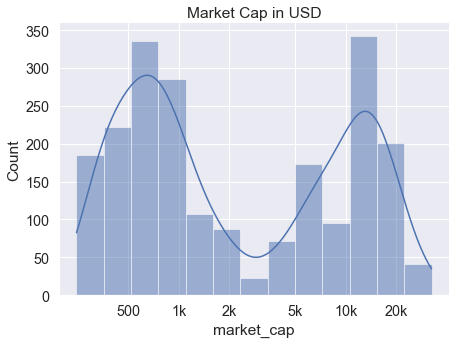

```python
f, ax = plt.subplots(figsize=(7, 5))
sns.despine(f)

sns.histplot(
    data = df_btc,
    x="market_cap",
    linewidth=.5,
    log_scale=True,
    kde=True,
).set(title="Market Cap in USD")
ax.xaxis.set_major_formatter(mpl.ticker.ScalarFormatter())
ax.set_xticks([5e9, 1e10, 2e10, 5e10, 1e11, 2e11], [500, '1k', '2k', '5k', '10k', '20k']);
```

> This gives us a clear picture of the distribution. The Bitcoin **Market Cap** distribution look bimodal. The data point peak between 500 to 1k and peak a little above 10K. Low points at the center between 2K to 5K and also a little above 20k.

> Market cap between 500 - 1k is the major mode.

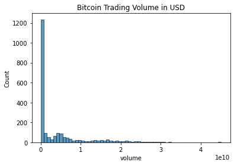

```python
sns.histplot(x='volume', data=df_btc).set(title="Bitcoin Trading Volume in USD");
```

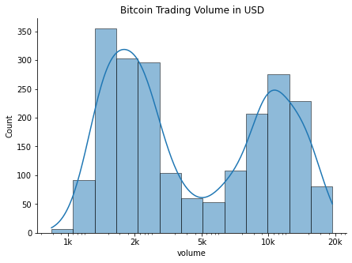

```python
f, ax = plt.subplots(figsize=(7, 5))
sns.despine(f)

sns.histplot(
    data = df_btc,
    x="volume",
    linewidth=.5,
    log_scale=True,
    kde=True,
).set(title="Bitcoin Trading Volume in USD")
ax.xaxis.set_major_formatter(mpl.ticker.ScalarFormatter())
ax.set_xticks(
    [5e6, 5e7, 5e8, 5e9, 5e10],
    ['1k', '2k', '5k', '10k', '20k']
);
```

> The Bitcoin **Volume** is skewed. When I defined a custom scale for the values, the distribution looks roughly bimodal, with one peak between 1,000 and a little above 2,000, and a second peak a little below 10,000 to a little below 20,000.

### Discuss the distribution(s) of your variable(s) of interest. Were there any unusual points? Did you need to perform any transformations?

The distribution of the **price** is right skewed and most data points frequent below 12,000 USD. The **market cap** and **volume** features took on a large range of values, so the data was display using a custom defined scale. Under the defined scale, the **market cap** and **volume** data looked bimodal.

### Of the features you investigated, were there any unusual distributions? Did you perform any operations on the data to tidy, adjust, or change the form of the data? If so, why did you do this?

When investigating the **price**, **market cap**, and **volume** I identified some anomalities. But in crypto, these extreme values are not unsual, rather they are expected, so no extreme values were removed.

## Bivariate Analysis

We may not investigate all the numeric features. Our numeric features of interest is the **price**, **market_cap**, and **volume**.

Let's look at for pairwise correlations which might present between these features in the bitcoin data.

```python
df_btc_numeric = df_btc[['price', 'market_cap', 'volume']]
```

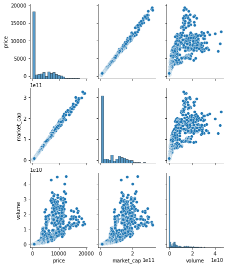

```python
sns.pairplot(df_btc_numeric, aspect=.85);
```

Let's use **Heatmap** to see the measure of these linear relationships among the numerical features of interest.

First, we run `df_btc_numeric.corr()` to get a table with the correlation coefficients.

```python
df_btc_numeric.corr()
```

|  | price | market_cap | volume |
| --- | --- | --- | --- |
| price | 1.000000 | 0.998797 | 0.784751 |
| market_cap | 0.998797 | 1.000000 | 0.801177 |
| volume | 0.784751 | 0.801177 | 1.000000 |

Create a **heatmap** of the above correlation coefficients table.

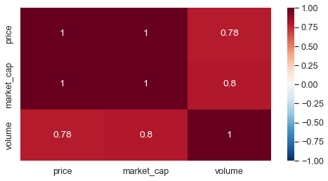

```python
sns.set(font_scale=1.15)
plt.figure(figsize=(8,4))
sns.heatmap(df_btc_numeric.corr(),
            cmap='RdBu_r',
            annot=True,
            vmin=-1, vmax=1);
```

**All numerical features are highly positively correlated features to one another.**

1. The higher the **market_cap** the higher the **price** and **market_cap** columns
2. The higher the **volume** the higher the **price** and **market_cap** columns
3. The higher the **price** the higher the **market_cap** and **volume**

Let's further explore these relationships using scatter(regplot) to show the trends.

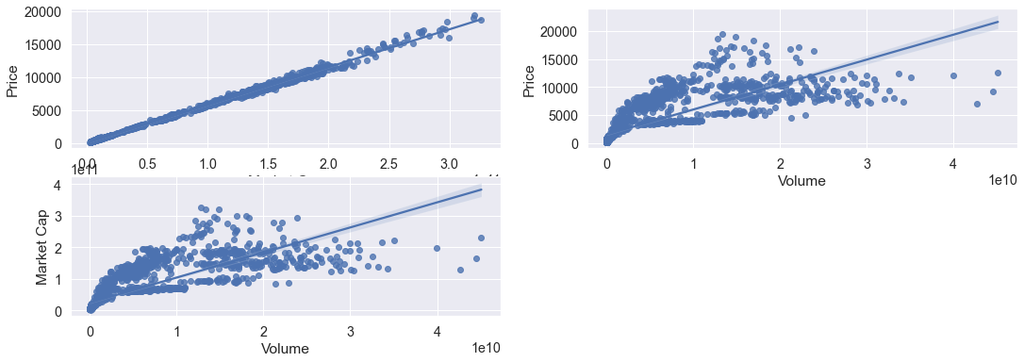

```python
plt.figure(figsize = [18, 6])
sns.set(font_scale=1.3)

# First Plot
plt.subplot(2, 2, 1)
sns.regplot(x = 'market_cap',
                y = 'price',
                data=df_btc)
plt.xlabel('Market Cap')
plt.ylabel('Price');

# Second Plot
plt.subplot(2, 2, 2)
sns.regplot(x = 'volume',
                y = 'price',
                data=df_btc)
plt.xlabel('Volume')
plt.ylabel('Price');

# Third Plot
plt.subplot(2, 2, 3)
sns.regplot(x = 'volume',
                y = 'market_cap',
                data=df_btc)
plt.xlabel('Volume')
plt.ylabel('Market Cap');
```

Let's see how the price of bitcoin has perform over the years

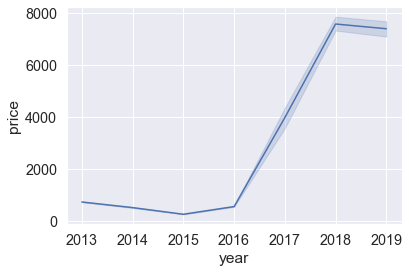

```python
sns.lineplot(
    x="year",
    y="price",
    data=df_btc,
    palette='bright');
```

> There was a sudden surge in price from 2016 to 2017

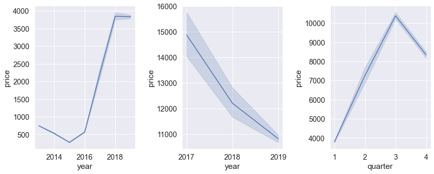

```python
fig = plt.figure(figsize= (12,5))

# plot on the left
df_btc_1000 = df_btc[df_btc['price'] < 5000]
# add subplot
ax=fig.add_subplot(1, 3, 1)
sns.lineplot(
    x="year",
    y="price",
    data=df_btc_1000,
    palette='bright');

# plot on the middle
df_btc_8000 = df_btc[df_btc['price'] > 10000]
# add subplot
ax=fig.add_subplot(1, 3, 2)
sns.lineplot(
    x="year",
    y="price",
    data=df_btc_8000,
    palette='bright');

# plot on the right
df_btc_2019 = df_btc[df_btc['year'] == 2019]
# add subplot
ax=fig.add_subplot(1, 3, 3)
sns.lineplot(
    x="quarter",
    y="price",
    data=df_btc_2019,
    palette='bright');

fig.tight_layout()
plt.show()
```

- The surge in price actually started in 2015 just after a massive fall from 2014.
- The price continue till late 2018 when it fell massively down to 3000 USD.
- There was also another surge in price in 2019 Q1 - Q3

### Talk about some of the relationships you observed in this part of the investigation. How did the feature(s) of interest vary with other features in the dataset?

Expected, all numerical features of interest are highly positively correlated to one another:

1. The higher the **market_cap** the higher the **price** and **market_cap** columns
2. The higher the **volume** the higher the **price** and **market_cap** columns
3. The higher the **price** the higher the **market_cap** and **volume**

### Did you observe any interesting relationships between the other features (not the main feature(s) of interest)?

There was a sudden surge in price from 2016 to 2017.

- The surge in price actually started in 2015 just after a massive fall from 2014.
- The **price** continue till late 2018 when it fell massively down to 3000 USD.
- There was also another surge in price in 2019 Q1 - Q3

## Multivariate Analysis

Let's have an overview on how bitcoin price perform in every year quarter since 2013

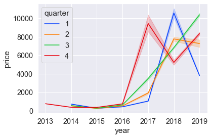

```python
sns.lineplot(
    x="year",
    y="price",
    data=df_btc,
    palette='bright',
    hue='quarter');
```

1. The price of bitcoin spike up consistently in Q3 with low decline
2. A spike in price is usually followed up by a sharp decline (and vice versa)

Let's further explore these observations.

Perform the same analysis at **price** < 1000 USD

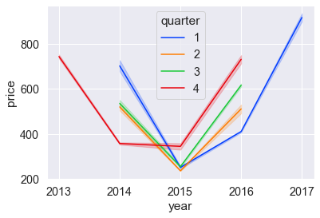

```python
df_btc_1000 = df_btc[df_btc['price'] < 1000]

sns.lineplot(
    x="year",
    y="price",
    data=df_btc_1000,
    palette='bright',
    hue='quarter');
```

> Like we observed in previous anaylsis: A sudden change in direction of the **price** is usually followed up by an opposite change in direction.

Let's analyse the quarter trend indepedently for each year.

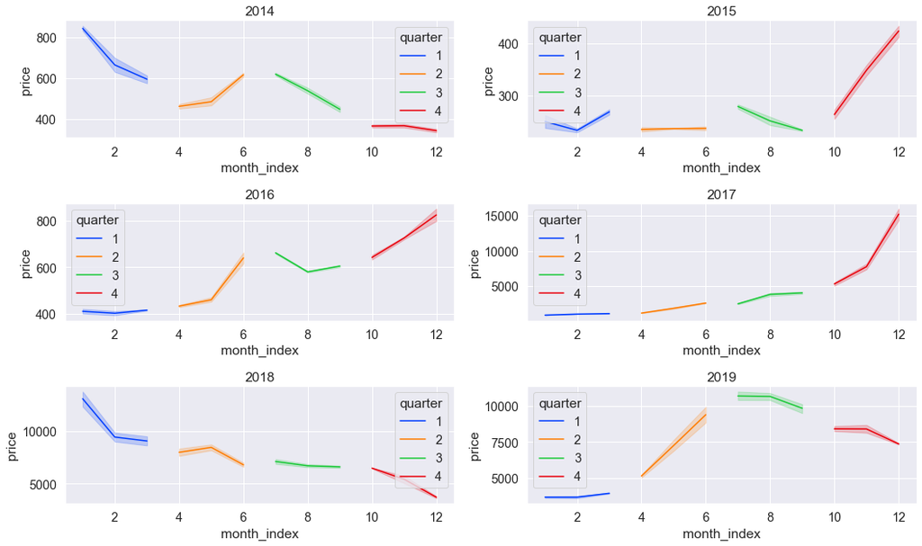

```python
import math

def plot_line_btc_year(x, y, hue):
    """ Quick function to a grid of line plots """
    unique_years = [2014, 2015, 2016, 2017, 2018, 2019]
    rows = math.ceil(len(unique_years) / 2)
    cols = 2
    count = 0

    # create figure
    fig = plt.figure(figsize= (15,9))

    for year in unique_years:
        count = count + 1
        df_btc_year = df_btc[df_btc['year'] == year].copy()
        df_btc_year['month_index'] = pd.DatetimeIndex(df_btc_year['date']).month

        # add subplot
        ax=fig.add_subplot(rows, cols, count)

        plt.subplot(rows, cols, count)
        # line plot bitcoin year performance data
        sns.lineplot(
            x=x,
            y=y,
            data=df_btc_year,
            palette='bright',
            hue=hue,
            ax=ax).set(title=year);


    fig.tight_layout()
    plt.show()

plot_line_btc_year(x='month_index', y='price', hue='quarter')
```

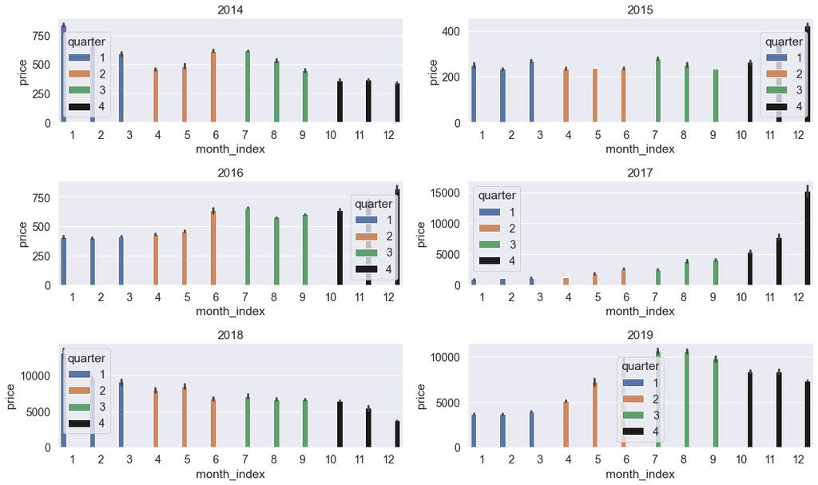

```python
def bar_plot_btc_year(x, y, hue):
    """ Quick function to a grid of bar plots """
    unique_years = [2014, 2015, 2016, 2017, 2018, 2019]
    rows = math.ceil(len(unique_years) / 2)
    cols = 2
    count = 0

    # create figure
    fig = plt.figure(figsize= (15,9))
    palette = {1: "C0", 2: "C1", 3: "C2", 4: "k"}

    for year in unique_years:
        count = count + 1
        df_btc_year = df_btc[df_btc['year'] == year].copy()
        df_btc_year['month_index'] = pd.DatetimeIndex(df_btc_year['date']).month

        # add subplot
        ax=fig.add_subplot(rows, cols, count)

        plt.subplot(rows, cols, count)
        # bar plot bitcoin year performance data
        sns.barplot(
            x=x,
            y=y,
            data=df_btc_year,
            hue=hue,
            ax=ax,
            palette=palette).set(title=year)


    fig.tight_layout()
    plt.show()

bar_plot_btc_year(x='month_index', y='price', hue='quarter');
```

### Talk about some of the relationships you observed in this part of the investigation. Were there features that strengthened each other in terms of looking at your feature(s) of interest?

In the previous analysis, the overall **price** of bitcoin increased over time. However, there is no worthy relationship between the **price** and time based features like (**months** and **quater**). If there is, probably is the observation that the price of bitcoin spike up consistently in Q3 with low decline.

### Were there any interesting or surprising interactions between features?

A sharp increase in the **price** is usually followed up by a sharp decrease (and vice versa) as the **date** increase.